# Red Wine Quality Analysis

# 2nd part of Univariate Analysis

### Did you create any new variables from existing variables in the dataset?

I have created 2 new variables. Total acidity and Combined sulfur dioxide. To check if there is any interesting relation between newly created variables..

### Bivariate Plots Selection

### part A:

Alcohol, volatile acidity, citric acid and sulphates are the most correlated attributes with quality. Next, I will dig in these variables to see their relationship with quality.

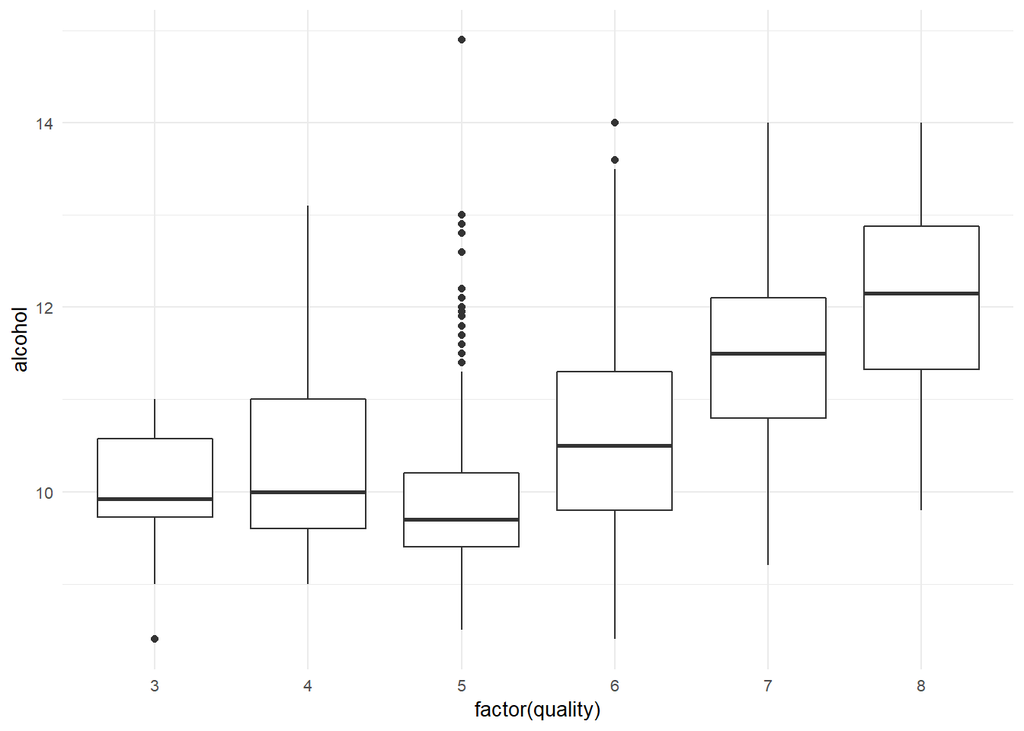

After looking at above box plot we can say that quality is positively correlated with alcohol

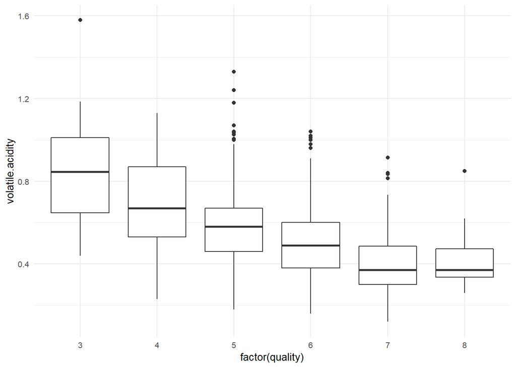

After looking at above box plot we can say that quality is inversely correlated with volatile acidity

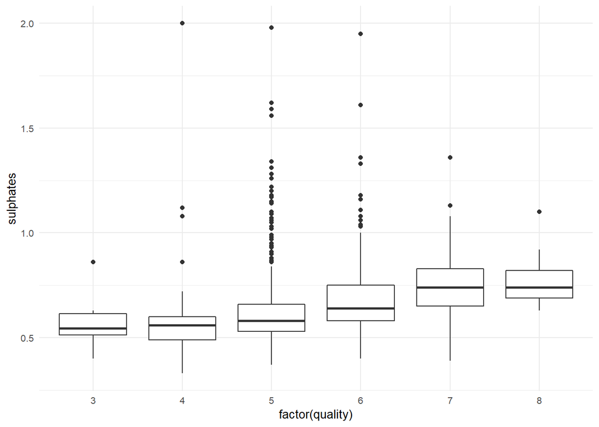

After looking at above box plot we can say that quality is slightly positively correlated with sulphates

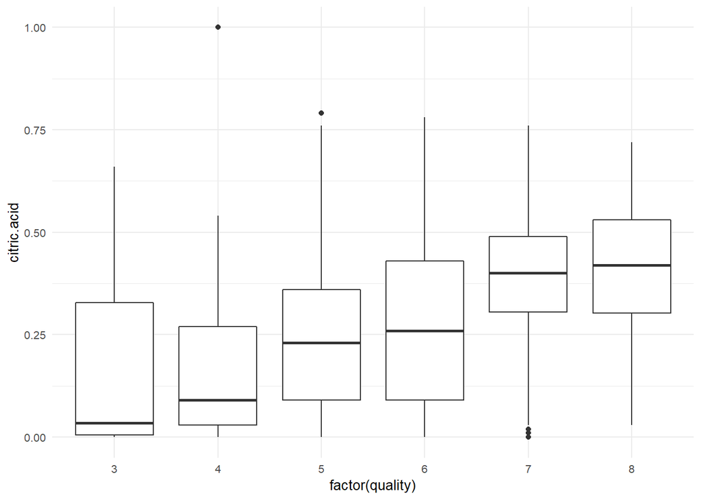

After looking at above box plot we can say that quality is positively correlated with citric acid

Let’s look at the scatter plot of above variables

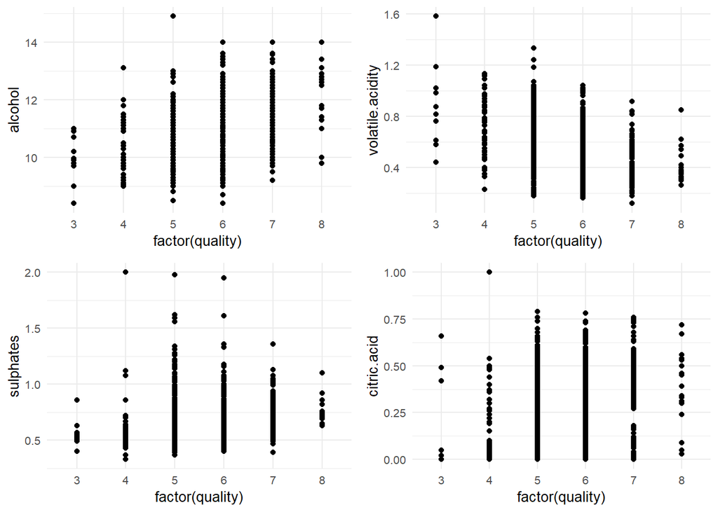

quality, alcohol, density, total.acidity, pH, citric acid (Part C)

- quality vs alcohol 0.476
- Alcohol vs density -0.496
- density vs total.acidity 0.685
- total.acidity vs pH -0.673
- pH vs citric acid -0.542
- citric acid vs total acidity 0.628

So above 6 variables are correlated strongly

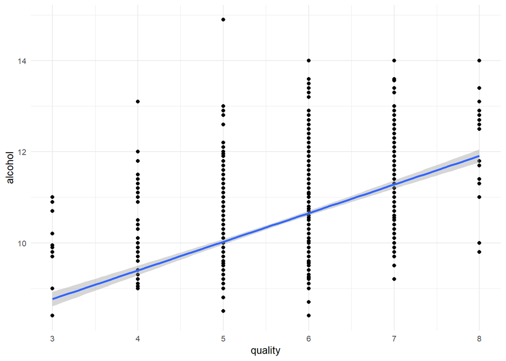

As Alcohol percentage is increasing, quality also increasing.

Alcohol vs density & density vs total.acidity

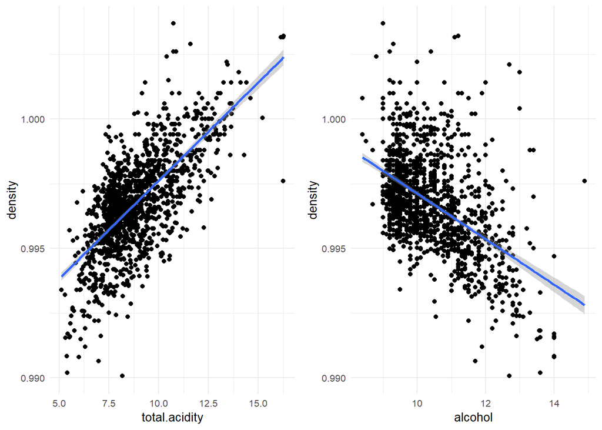

Density vs total.acidity shows a strong positive correlation. i.e more acids means more dense.

Density vs Alcohol shows a strong negative correlation. More alcohol percentage means less density.

Total Acidity vs Citric Acid and pH vs Citric acid

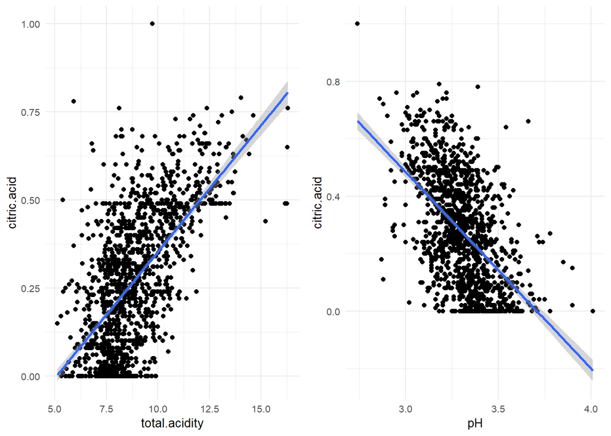

Citric acid increases total acidity increses

Citric acid increases pH decreases

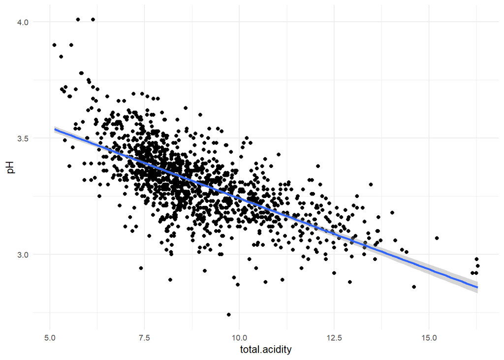

Total acidity increases pH decreases

### Talk about some of the relationships you observed in this part of the investigation. How did the feature(s) of interest vary with other features in the dataset?

- As Alcohol percentage is increasing, quality also increasing.
- Quality is positively correlated with citric acid
- Quality is inversely correlated with volatile acidity.
- Quality is slightly positively correlated with sulphates

### Did you observe any interesting relationships between the other features (not the main feature(s) of interest)?

- Density vs total.acidity shows a strong positive correlation. i.e more acids means more dense.
- Density vs Alcohol shows a strong negative correlation. More alcohol percentage means less density.
- citric acid increases total acidity increses
- Citric acid increases pH decreases
- Total acidity increases pH decreases

### What was the strongest relationship you found?

- Thease are the strongest correlations I found
- density vs total.acidity 0.685
- fixed.acidity vs pH -0.683
- total.acidity vs pH -0.673
- Citric acid vs fixed acidity 0.672
- density vs fixed.acidity 0.668

### Multivariate

As alcohol is strongly correlated to quality I want to explore Alcohol vs other variables over quality

### 3. Multivariate Section

This section includes plots and analysis of multiple variables

### 3.1 Multivariate Plots

As correlation is strong for (quality vs other variables)

Correlation above 0.2 is there for volatile.acidity, citric.acid, sulphates, alcohol

### Part A

**Alcohol vs. Other Variables over Quality**

Darker the color better the wine

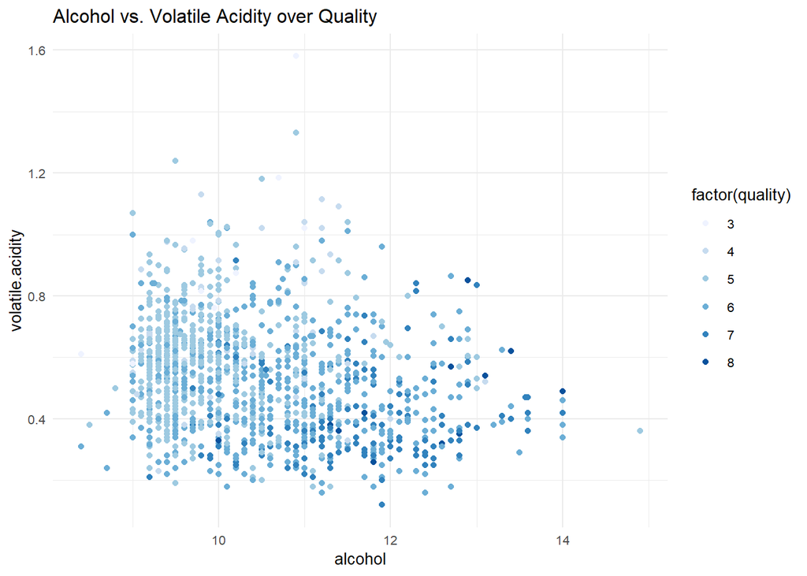

High quality wines are having less volatile acidity levels. As usual if alcohol percentage increases , quality also increases.

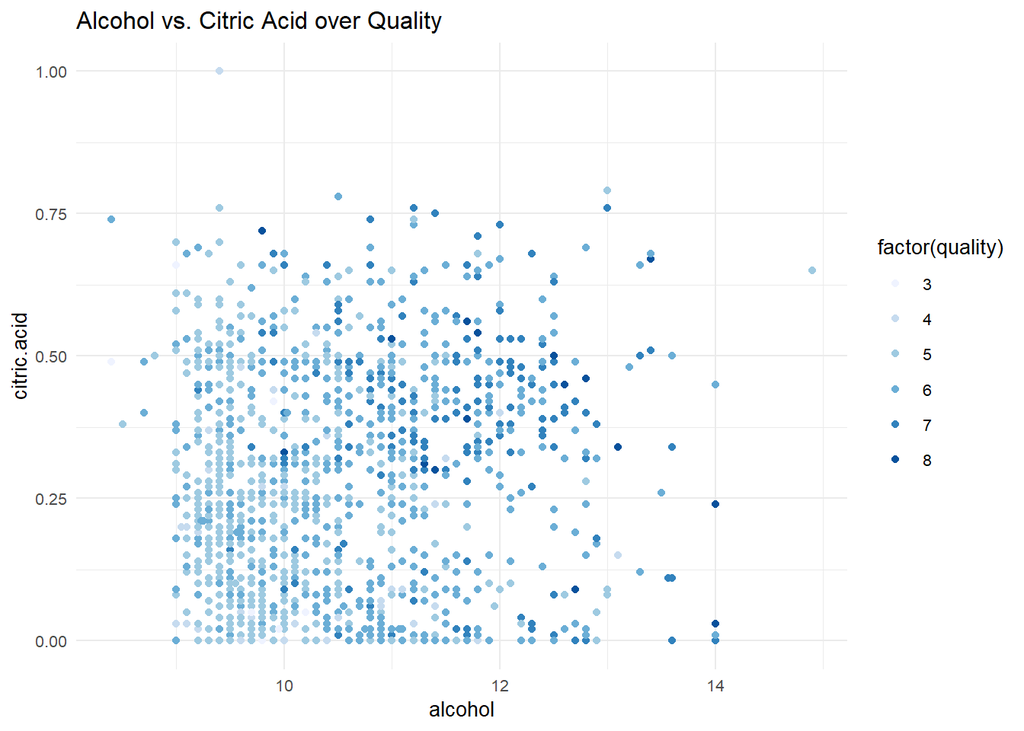

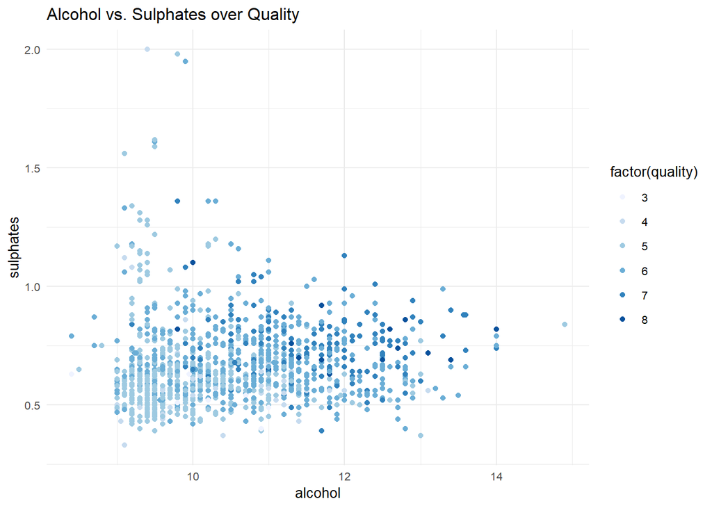

In the above plot darker points are in between 0.75 - 1 levels of sulphates and very few number of high quality wines are above 1. So sulphates are lghtly infulencing qulaity of wine.

But alcohol percenatge of 11 and above are having mostly best quality wines.

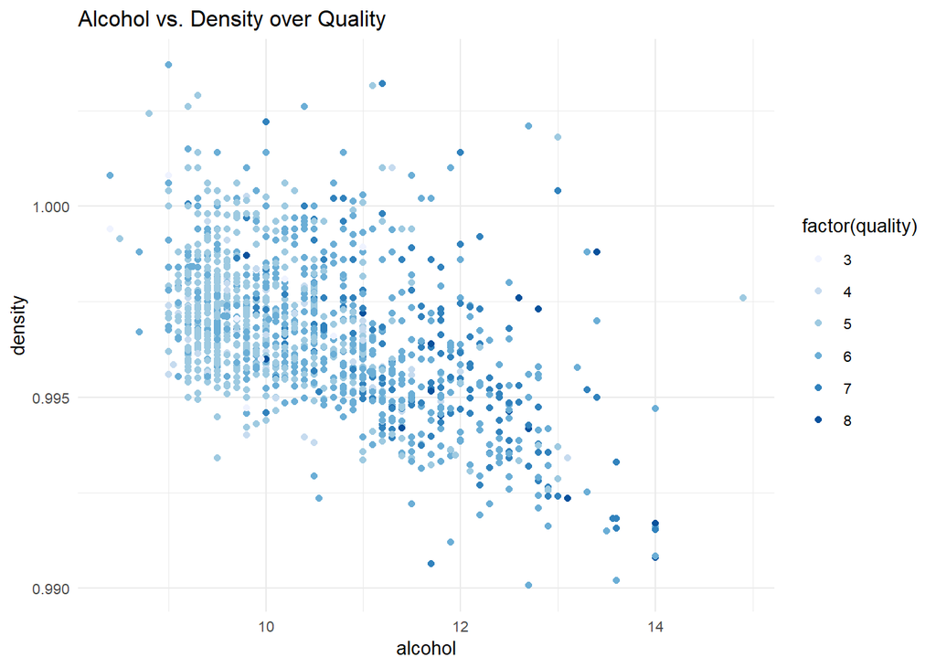

Good quality of wines are in between 0.9925 - 0.9975

Darkers spots(high quality wines) are easily identified(When alcohol content increases in above graph, for lower density levels)

Quality increases w.r.t alcohol percentage

Quality increases within a range of sulphate levels. That means below the range and above the range, very few wines are present.

Less volatile acidity means better quality

Quality increases if wines are in between 0.25 - 0.75 levels of citric acid.

Quality increses When alcohol content increases in above graph, for lower density levels

** According to New Redwine set( Including two newly created variables) below 6 variables are correlated strongly. ** * density vs total.acidity 0.685 * total.acidity vs pH -0.673 * pH vs citric acid -0.542 * citric acid vs total acidity 0.628 * quality, alcohol, density, total.acidity, pH, citric acid

I want to consider the new redwine dataset, because it has total acidity(fixed acidity + volatile acidity)

**Multivariate Plots of other Variables**

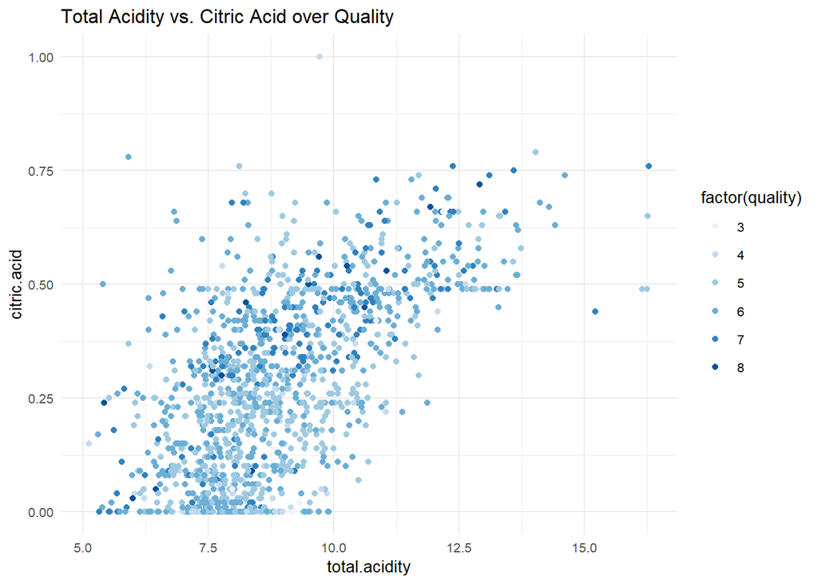

High quality wines are in between 0.25 to 0.75 levels of citric acid and below total acidity levels of 12.5

Increase in citric acid increases total acidity. Wine quality also increases in between 0.25 to 0.75 levels of citric acid and below total acidity levels of 12.5

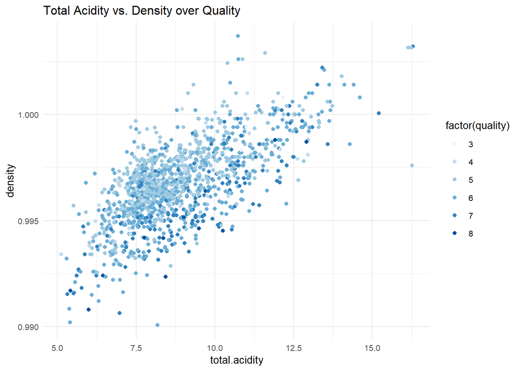

High quality wines are in lower density levels i.e beloow 0.9975 and above 0.9925 and less that 12.5 of total acidity levels

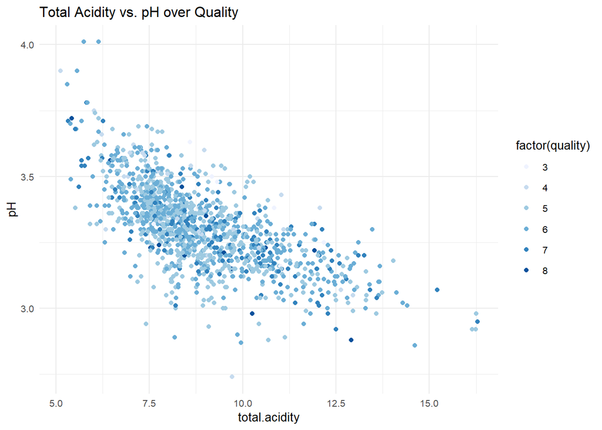

pH increases total acidity decreases. Best quality wines are allover the plot, Looks like total acidity and quality are not at all related.

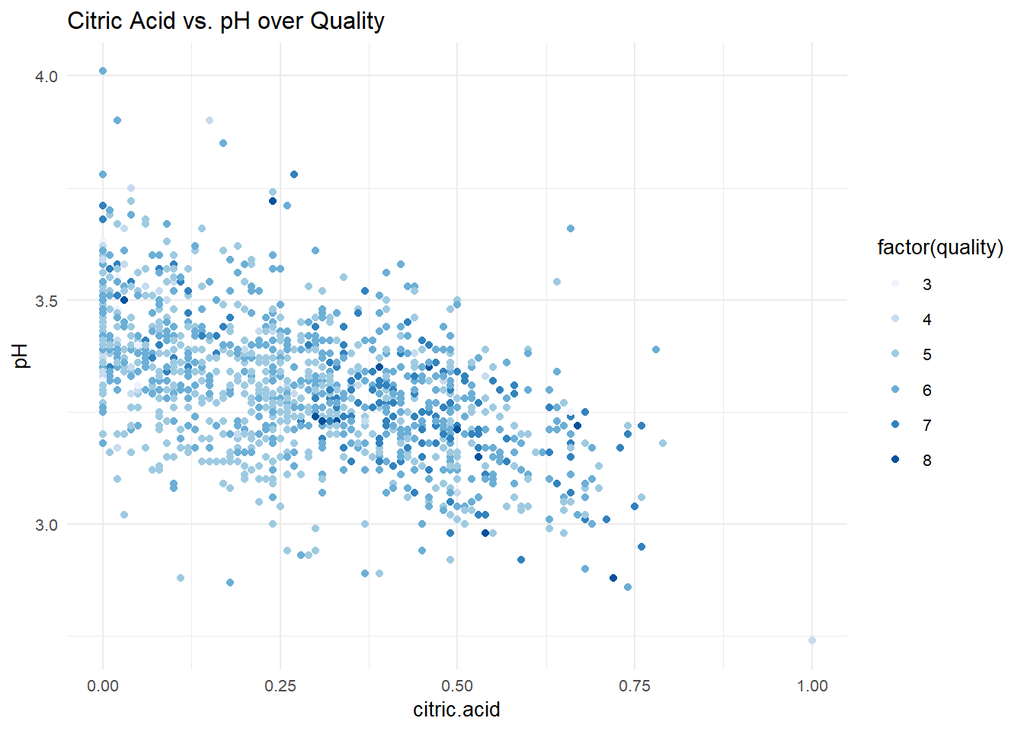

Best quality wines are mostly present when pH decreases and citric acid increases(0.25-0.75)

#### 3.2 Multivariate Analysis

### Talk about some of the relationships you observed in this part of the investigation. Were there features that strengthened each other in terms of looking at your feature(s) of interest?

After investigating multivariate plots, these are my observations.

- Quality increases w.r.t alcohol percentage
- Quality increases within a range of sulphate levels. That means below the range and above the range, very few wines are present.
- Less volatile acidity means better quality
- Quality increases if wines are in between 0.25 - 0.75 levels of citric acid.
- Quality increses When alcohol content increases in above graph, for lower density levels

### Were there any interesting or surprising interactions between features?** pH vs Total acidity vs quality plot:

pH increases total acidity decreases. Best quality wines are allover the plot, Looks like total acidity and quality are not at all related.

Where as volatile acidity graph is showing that Less volatile acidity means better quality

In the sulphates vs alcohol vs quality plot darker points are in between 0.75 - 1 levels of sulphates and very few number of high quality wines are above 1. So sulphates are lghtly infulencing qulaity of wine. But alcohol percenatge of 11 and above are having mostly best quality wines.

Correlation is very less between so2 and quality

### Plot One

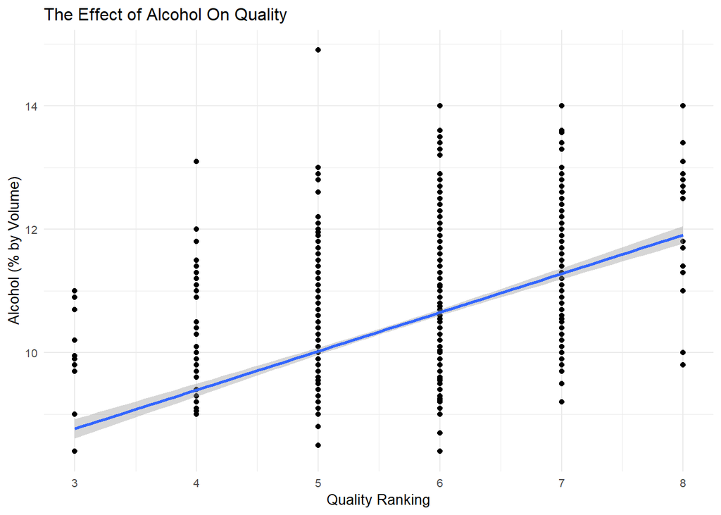

### Description One

The above chart shows how increase in alcohol percent highly effects the quality of wine.

### Plot Two

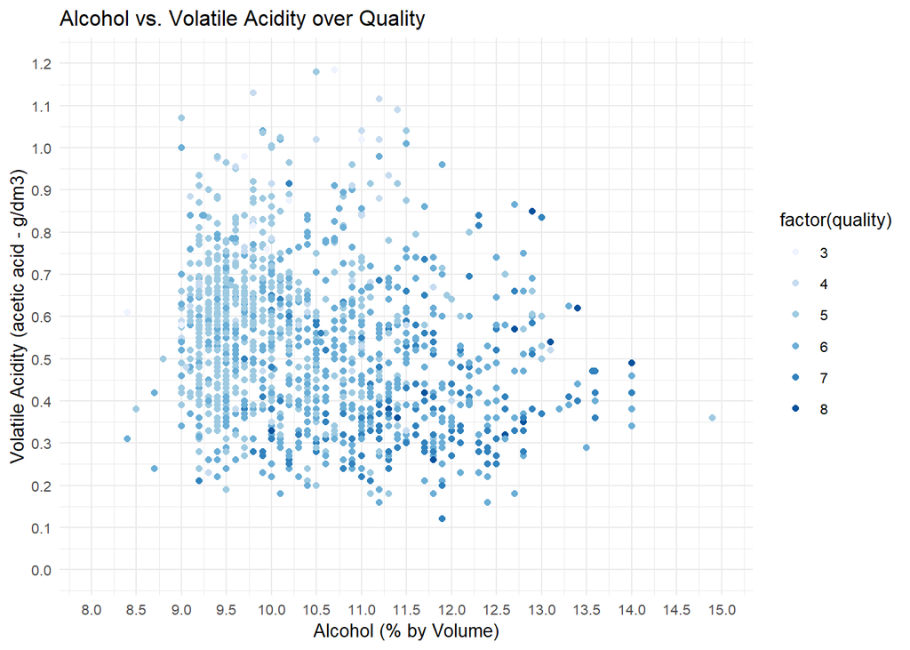

### Description Two

- High quality wines are having less volatile acidity levels. As usual if alcohol percentage increases , quality also increases.
- So High quality wine with the highest alcohol percentage, should also contain low volatile acidity

### Plot Three

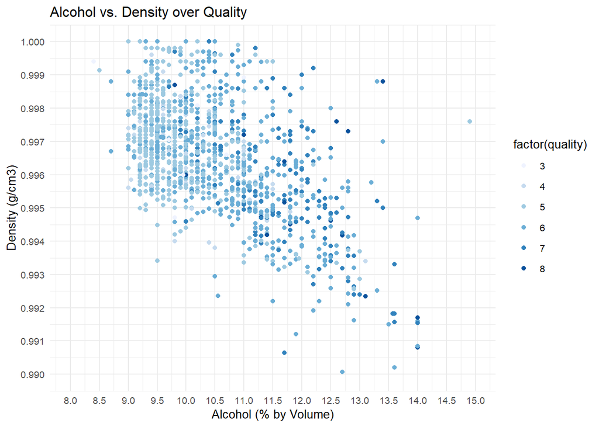

### Description Three

- Good quality of wines are in between 0.9925 - 0.9975
- Darkers spots(high quality wines) are easily identified(When alcohol content increases in above graph, for lower density levels)
- That means density of wine is inversely proportional to alcohol.

# Reflection

** Reflect on the exploration you performed and the insights you found.**

It’s really a great experience investigating and exploring red wine data. Before this project, I just heard wine. I don’t know much about it. But now I learned a lot from data about quality of wine.

- First, I have investigated each variable individually, and tried to analyze the distributions using histograms. For skewed and long tailed distributions, I have used log10 , sqrt to rescale the variables.
- Next, I have calculated the correlationof each variable individually and also plotted correlation matrix using ggpair. I have created different correlation matrix for newly created variables also. These helped me a lot.
- Next, in bivariate section, I explored the relationships between variable combinations with good Correlation.
- Finally, I have done multivariate analysis, which gave me my final insight about the data.

Observations from my analysis:

1. Increase in Alcohol percentage, increases the quality.
2. Best quality wines are mostly present when pH decreases and citric acid increases
3. pH increases total acidity decreases. Best quality wines are allover the plot, Looks like total acidity and quality are not at all related.
4. High quality wines are in lower density levels
5. sulphates are lghtly infulencing qulaity of wine.
6. High quality wines are having less volatile acidity levels. As usual if alcohol percentage increases , quality also increases.

**What were some of the struggles that you went through?**

I don’t know anything about wine making and its components. I read many online materials, blogs and repeated Udacity videos many times. This project took longer time than expected.

** What went well? What was surprising? Where did I find successes?**

I have tried to investigate in many ways. Correlation matrix helped me in my analysis. First surprise was, I didnt taste wine, but completed my analysis. Next surprise was the relation between variable. How different chemicals are increasing or decreasing the quality.

**Make sure you include an insight into future work that could be done with the dataset.**

Eventhough I have created new variables, I felt like if more data is availble, we can plot and predict more trends. In real world so many factors affect the quality of red wine, So for future analysis if we collect the follwing data, it’s helpful in our analysis.

- Type of grapes used for preparing wine
- Taste of wine( sweet or sour)
- Fermentation time
- Cost of the wine(production). Because preference is given to high quality wine with less cost

### References

https://www.bbr.com/wine-knowledge/faq-quality

http://davidmlane.com/hyperstat/A92403.html

https://www.mathsisfun.com/data/skewness.html

https://www.statisticshowto.datasciencecentral.com/probability-and-statistics/skewed-distribution/

Mentor Dylan

Mentor Myles

https://rpubs.com/Daria/57835

http://www.sthda.com/english/wiki/ggplot2-scatter-plots-quick-start-guide-r-software-and-data-visualization#scatter-plots-with-multiple-groups

Udacity videos and Notes on exploratory Data Analysis